# Economic Data 2026 - Labs

Week 4

*Aims*: Familiarise yourself with Eurostat, data cleaning, functions, and combining datasets in R.

Your country depends on the timing of your lab session:

- Monday: Norway
- Tuesday: Germany
- Wednesday: Spain
- Thursday: France

## Part 1 (Functions)

In this exercise, we will see how to write our own functions. The exercise builds on part 1 from lab 3. It is useful to have your lab_3.R file open. The growth rate between year $t$ and $t-1$ is approximated by
$$\begin{equation}
g_t = 100 \times \left(\ln (GDP_t) - \ln(GDP_{t-1})\right),
\end{equation}$$
where $\ln$ denotes the natural logarithm.

- Open an R script and save it as lab_4.R.
- Open the data on real GDP that you worked on for part 1 of lab 3. Write the command for importing the dataset at the top of your script. Assign the dataset the name `df`.
- Keep only the columns in `df` with data on the year and GDP.
- Rename the columns in your dataset to `year` and `gdp`.
- Copy the function below and paste it into your script.

```r
# Function to calculate the mean of the log
log_mean <- function(x) {
  log_mean <- mean(log(x))
  return(log_mean)
}
```

- Calculate the mean of the logarithm of GDP using the function. **Hint**: Use the same syntax as for other functions you have seen such as `mean()`, `sum()`, or `log()`.
- Use the function below to generate the lag of GDP.

```r
# Function to calculate the lagged value of a vector
lagged_value <- function(current_value) {
  previous_value <- c(NA, current_value[-length(current_value)])
  return(previous_value)
}
```

- Write a function called `calculate_growth_rate()` that calculates the growth rate of a vector. **Hint**: Combine the previous functions and have a look at the solutions from week 3.
- Calculate the growth rate of GDP by using the function `calculate_growth_rate()` and assign this to a new column in the dataset. Name this new column `gdp_g`.
- Calculate some descriptive statistics for the growth rate. **Hint**: Use the functions from this week’s lecture. `na.rm = TRUE` as an option in the function removes missing values before each calculation.
- Export `df` to a CSV form. **Hint**: Use the function `write.csv()`.
- Construct the histogram below. **Hint**: Use the function `hist()`.
- Comment on the growth performance of your country over the time period.

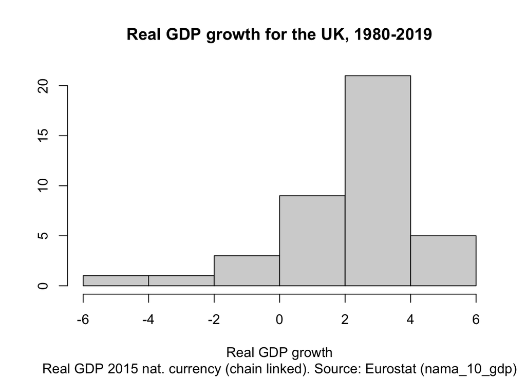

## Part 2 (Merging Dataframes)

In this exercise, we will construct a scatter plot of life satisfaction and GDP per capita using R and data from Eurostat.

- Go to https://ec.europa.eu/eurostat/en/ and download data on “Overall life satisfaction” for as many countries and years as possible (you don’t have to select a specific sex and education).
- From the same website, download data on GDP per capita in constant prices for as many years and countries as possible.
- Load and clean the data on life satisfaction and assign the dataset the name `life_sat` (remove missing values, rename variables to meaningful and manageable names, and select the relevant columns).
- Load and clean the data on GDP per capita and assign the dataset the name `gdppc` (remove missing values, rename variables to meaningful and manageable names, and select the relevant columns).
- Combine the two datasets by matching on `year` and `country`. Name the combined dataframe `df_combined`. **Hint**: Use the function `merge(life_sat, gdppc, by = c('country', 'year'), all = TRUE)`
- Remove rows in `df_combined` with missing values in either the data on GDP per capita or life satisfaction. **Hint**: You can subset `df_combined` using the condition `!is.na()`.
- Construct the plot below using the commands below. **Hint**: You can keep the years $2013$, $2018$, and $2023$ by subsetting `df_combined` using the condition `df_combined$year %in% c(2013, 2018, 2023)`.

```r
## Plotting the data using base R
plot(df$gdppc, df$life_sat,
     pch = as.numeric(as.factor(df$year)), # Shapes for different years
     xlab = "Real GDP per capita",
     ylab = "Overall life satisfaction (1=lowest, 10=highest)",
     main = "Life satisfaction vs. GDP per capita",
     sub = "Real GDP 2015 national currency (chain linked). Source: Eurostat (nama_10_pc)")

## Add a legend
legend("bottomright", legend = unique(df$year),
       pch = unique(as.numeric(as.factor(df$year))),
       title = "Year")
```

- Export the plot as a pdf and add it to a Word file. Write 100 words explaining what the variables measure and about some patterns in the data. **Hint**: You can click export in the plot window to export a plot.
- Construct a function that returns the correlation between life satisfaction and GDP per capita for a user specified year. Call the function `correlation_year()`. Round the number of digits to $2$ **Hint**: Embed the solution to Part 2 of the exercise into the function `correlation_year()`. Use `round( , digits = 2)`

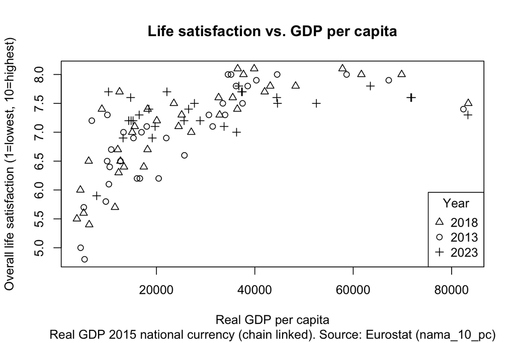